# Fast_food_nutrition

# **Question: How does the nutritional content of fast food items differ between franchises?**

**Dataset used: https://www.kaggle.com/datasets/ulrikthygepedersen/fastfood-nutrition**

**1) Load Tidyverse and fastfood.csv file**

```r
library(tidyverse)
fastfood_df <- read_csv("fastfood.csv")
```

**2) Clean data to isolate the following variables: Calories, Saturated Fats, Sodium, and Sugar Rationale: Labels that have adverse health affects (but we subbed sugar since there is no added sugar)**

https://www.fda.gov/food/new-nutrition-facts-label/how-understand-and-use-nutrition-facts-label#:~:text=Saturated%20fat%2C%20sodium%2C%20and%20added%20sugars%20are%20nutrients%20listed%20on,nutrients%20to%20get%20less%20of.

```r
fastfood_df %>% select(1, 2, 3, 6, 9, 12)
```

| restaurant | item | calories | sat_fat | sodium | sugar |
| --- | --- | --- | --- | --- | --- |
| Mcdonalds | Artisan Grilled Chicken Sandwich | 380 | 2.0 | 1110 | 11 |
| Mcdonalds | Single Bacon Smokehouse Burger | 840 | 17.0 | 1580 | 18 |
| Mcdonalds | Double Bacon Smokehouse Burger | 1130 | 27.0 | 1920 | 18 |
| Mcdonalds | Grilled Bacon Smokehouse Chicken Sandwich | 750 | 10.0 | 1940 | 18 |
| Mcdonalds | Crispy Bacon Smokehouse Chicken Sandwich | 920 | 12.0 | 1980 | 18 |
| Mcdonalds | Big Mac | 540 | 10.0 | 950 | 9 |
| Mcdonalds | Cheeseburger | 300 | 5.0 | 680 | 7 |
| Mcdonalds | Classic Chicken Sandwich | 510 | 4.0 | 1040 | 6 |
| Mcdonalds | Double Cheeseburger | 430 | 11.0 | 1040 | 7 |
| Mcdonalds | Double Quarter Pounder® with Cheese | 770 | 21.0 | 1290 | 10 |

[output cut: 505 more lines]

**3) Create variable box plots, descriptive statistics, and scatterplots of Calories vs Variables**

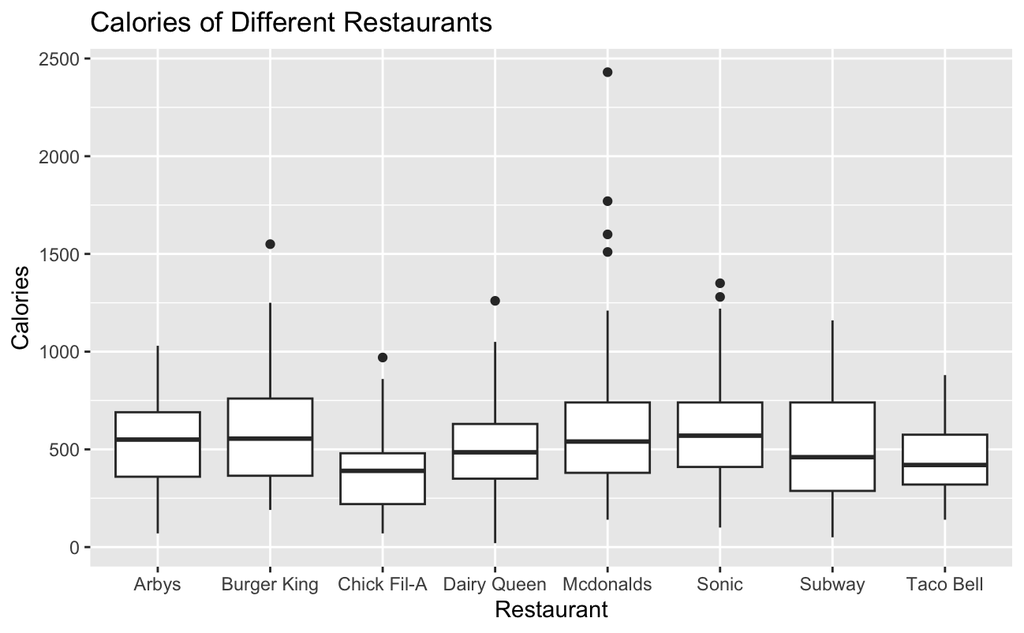

```r
#Boxplots of the categories and descriptive statistics

#calories
ggplot(fastfood_df, aes(x = restaurant, y = calories)) +
  geom_boxplot() +
  labs(title = "Calories of Different Restaurants",
       x = "Restaurant",
       y = "Calories")
```

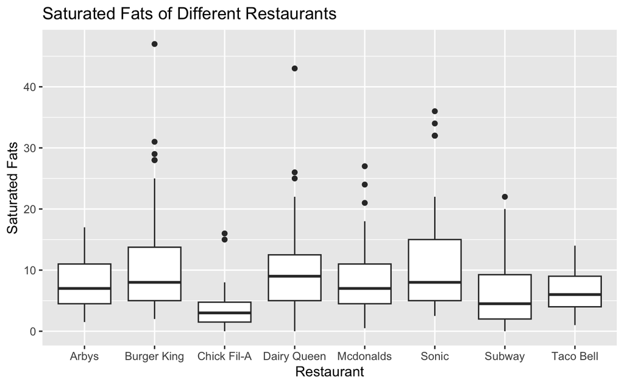

```r
#sat_fat
ggplot(fastfood_df, aes(x = restaurant, y = sat_fat)) +
  geom_boxplot() +
  labs(title = "Saturated Fats of Different Restaurants",
       x = "Restaurant",
       y = "Saturated Fats")
```

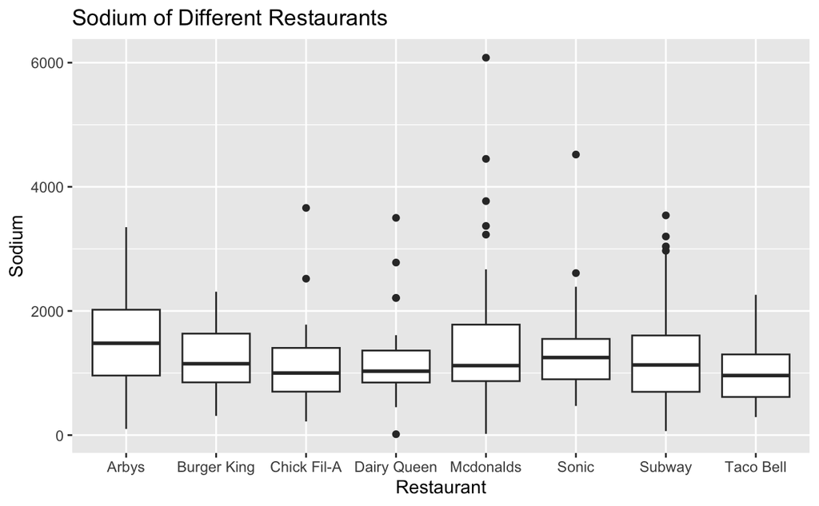

```r
#sodium
ggplot(fastfood_df, aes(x = restaurant, y = sodium)) +
  geom_boxplot() +
  labs(title = "Sodium of Different Restaurants",
       x = "Restaurant",
       y = "Sodium")
```

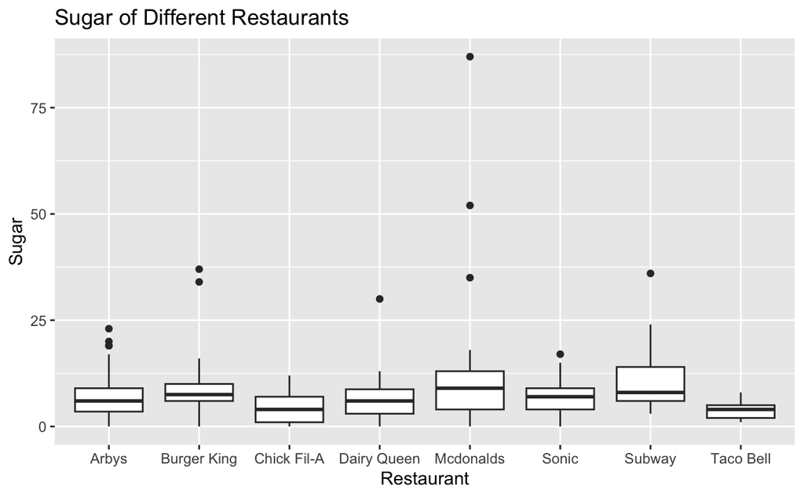

```r
#sugar
ggplot(fastfood_df, aes(x = restaurant, y = sugar)) +
  geom_boxplot() +
  labs(title = "Sugar of Different Restaurants",
       x = "Restaurant",
       y = "Sugar")
```

```r
#Descriptive statistics

fastfood_stats <- fastfood_df %>%
  group_by(restaurant) %>%
  summarise(
    Mean_calories = mean(calories),
    SD_calories = sd(calories),
    Min_calories = min(calories),
    Max_calories = max(calories),
    Mean_sat_fat = mean(sat_fat),
    SD_sat_fat = sd(sat_fat),
    Min_sat_fat = min(sat_fat),
    Max_sat_fat = max(sat_fat),
    Mean_sodium = mean(sodium),
    SD_sodium = sd(sodium),
    Min_sodium = min(sodium),
    Max_sodium = max(sodium),
    Mean_sugar = mean(sugar),
    SD_sugar = sd(sugar),
    Min_sugar = min(sugar),
    Max_sugar = max(sugar),
  )

print(fastfood_stats)
```

| restaurant | Mean_calories | SD_calories | Min_calories | Max_calories | Mean_sat_fat | SD_sat_fat | Min_sat_fat | Max_sat_fat | Mean_sodium | SD_sodium | Min_sodium | Max_sodium | Mean_sugar | SD_sugar | Min_sugar | Max_sugar |
| --- | --- | --- | --- | --- | --- | --- | --- | --- | --- | --- | --- | --- | --- | --- | --- | --- |
| Arbys | 532.7273 | 210.3388 | 70 | 1030 | 7.972727 | 4.162685 | 1.5 | 17 | 1515.273 | 663.6651 | 100 | 3350 | 7.563636 | 5.858718 | 0 | 23 |
| Burger King | 608.5714 | 290.4184 | 190 | 1550 | 11.150000 | 8.767674 | 2.0 | 47 | 1223.571 | 499.8841 | 310 | 2310 | 8.185714 | 6.186223 | 0 | 37 |
| Chick Fil-A | 384.4444 | 220.4948 | 70 | 970 | 4.111111 | 3.903483 | 0.0 | 16 | 1151.481 | 726.9203 | 220 | 3660 | 4.148148 | 3.665890 | 0 | 12 |
| Dairy Queen | 520.2381 | 259.3377 | 20 | 1260 | 10.440476 | 8.252274 | 0.0 | 43 | 1181.786 | 609.9398 | 15 | 3500 | 6.357143 | 5.025891 | 0 | 30 |
| Mcdonalds | 640.3509 | 410.6961 | 140 | 2430 | 8.289474 | 5.534750 | 0.5 | 27 | 1437.895 | 1036.1721 | 20 | 6080 | 11.070175 | 13.345491 | 0 | 87 |
| Sonic | 631.6981 | 300.8816 | 100 | 1350 | 11.415094 | 8.667321 | 2.5 | 36 | 1350.755 | 665.1340 | 470 | 4520 | 6.528302 | 3.944830 | 0 | 17 |
| Subway | 503.0208 | 282.2210 | 50 | 1160 | 6.197917 | 5.241775 | 0.0 | 22 | 1272.969 | 743.6346 | 65 | 3540 | 10.093750 | 5.608411 | 3 | 36 |
| Taco Bell | 443.6522 | 184.3449 | 140 | 880 | 6.591304 | 2.981362 | 1.0 | 14 | 1013.913 | 474.0544 | 290 | 2260 | 3.704348 | 1.887047 | 1 | 8 |

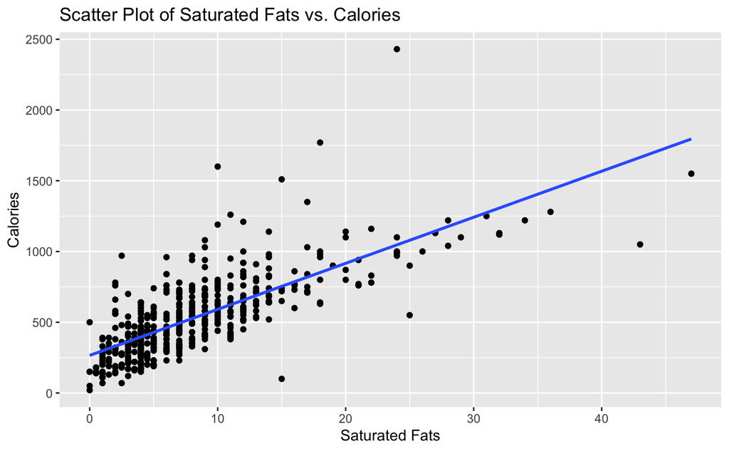

```r
#Scatter plot of Calories vs other variables

#calories vs sat_fat
ggplot(fastfood_df, aes(x = sat_fat, y = calories)) +
  geom_point() +
  geom_smooth(method = "lm", se = FALSE) +
  labs(title = "Scatter Plot of Saturated Fats vs. Calories",
       x = "Saturated Fats",
       y = "Calories")
```

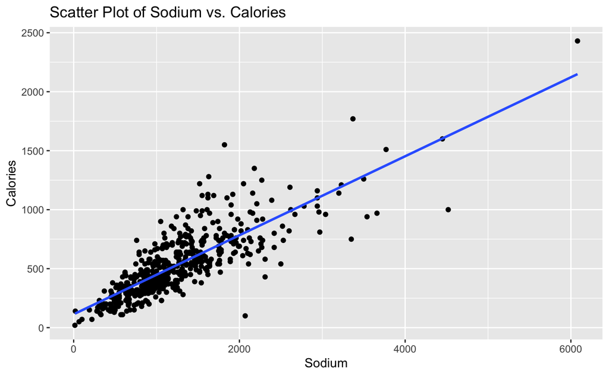

```r
#calories vs sodium
ggplot(fastfood_df, aes(x = sodium, y = calories)) +
  geom_point() +
  geom_smooth(method = "lm", se = FALSE) +
  labs(title = "Scatter Plot of Sodium vs. Calories",
       x = "Sodium",
       y = "Calories")
```

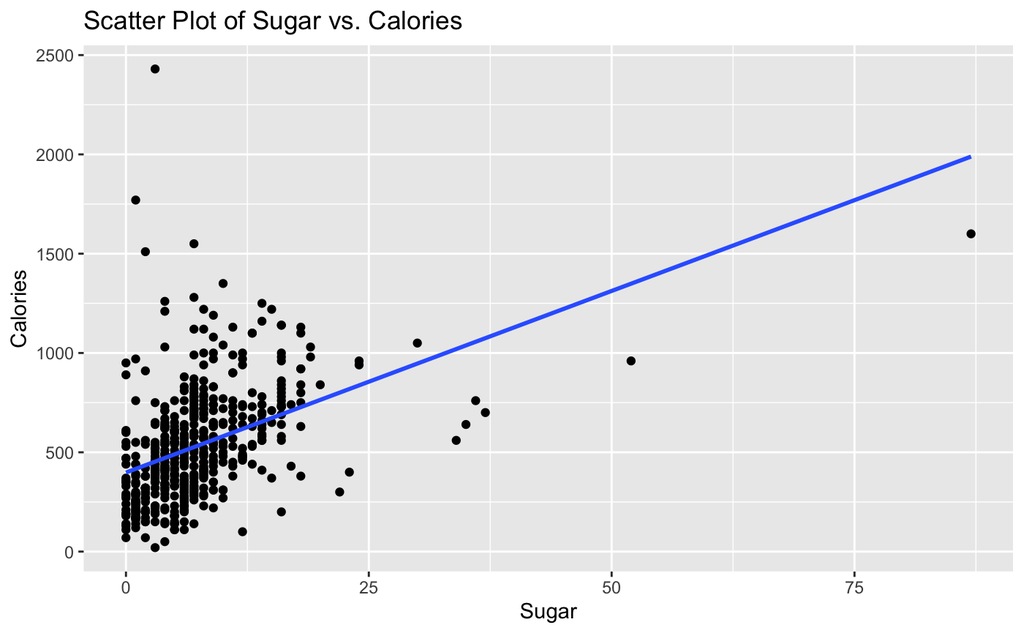

```r
#calories vs sugar
ggplot(fastfood_df, aes(x = sugar, y = calories)) +
  geom_point() +
  geom_smooth(method = "lm", se = FALSE) +
  labs(title = "Scatter Plot of Sugar vs. Calories",
       x = "Sugar",
       y = "Calories")
```

Answer: A positive correlation between calories and saturated fats and calories and sodium. Unsure about calories and sugar.

Next step: Confirm this visual interpretation by finding out how to code and display the R^2 values and trendline equation.

**4) Index top 20 overall in each of the 4 categories and then pie chart to see which restaurant contributes the most.**

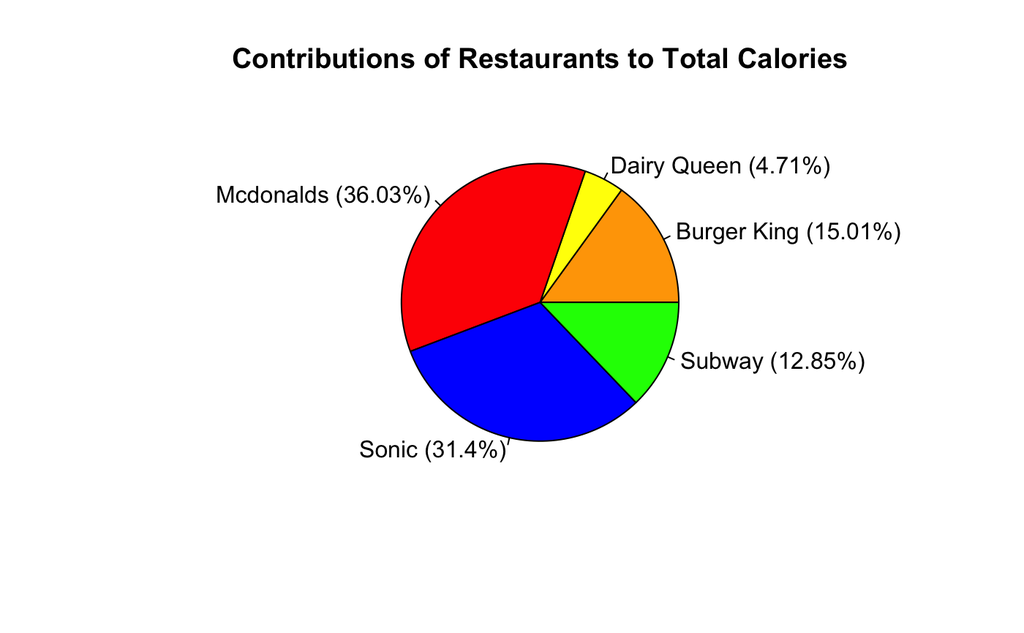

```r
#Select top 20 items in each category
top_20_calories <- fastfood_df %>%
  arrange(desc(calories)) %>%
  slice(1:20) %>%
  select(1,2,3)

# Group menu items by restaurant and calculate the total calories
restaurant_calories <- aggregate(calories ~ restaurant, data = top_20_calories, FUN = sum)

# Calculate the total calories
total_calories <- sum(restaurant_calories$calories)

# Calculate the percentage of calories for each restaurant
restaurant_calories$percentage <- round(restaurant_calories$calories / total_calories * 100, 2)

# Create the pie chart with percentages
colors <- c("orange", "yellow", "red", "blue", "green")
labels <- paste(restaurant_calories$restaurant, " (", restaurant_calories$percentage, "%)", sep = "")

pie(restaurant_calories$calories, labels = labels, col = colors, main = "Contributions of Restaurants to Total Calories")
```

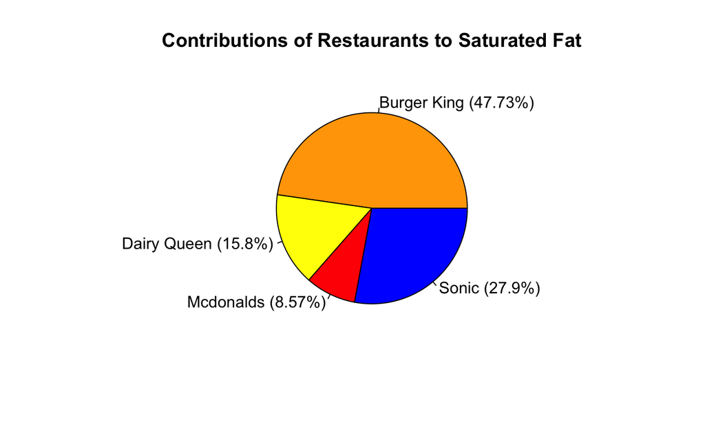

```r
top_20_satfats <- fastfood_df %>%
  arrange(desc(sat_fat)) %>%
  slice(1:20) %>%
  select(1,2,6)

restaurant_satfats <- aggregate(sat_fat ~ restaurant, data = top_20_satfats, FUN = sum)

total_satfats <- sum(restaurant_satfats$sat_fat)

restaurant_satfats$percentage <- round(restaurant_satfats$sat_fat / total_satfats * 100, 2)

colors <- c("orange", "yellow", "red", "blue")
labels <- paste(restaurant_satfats$restaurant, " (", restaurant_satfats$percentage, "%)", sep = "")

pie(restaurant_satfats$sat_fat, labels = labels, col = colors, main = "Contributions of Restaurants to Saturated Fat")
```

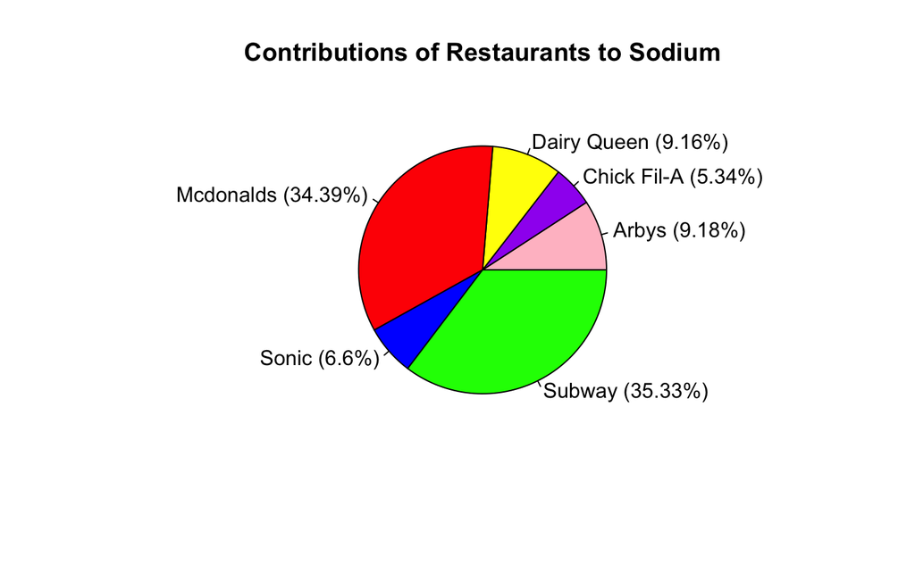

```r
top_20_sodium <- fastfood_df %>%
  arrange(desc(sodium)) %>%
  slice(1:20) %>%
  select(1,2,9)

restaurant_sodium <- aggregate(sodium ~ restaurant, data = top_20_sodium, FUN = sum)

total_sodium <- sum(restaurant_sodium$sodium)

restaurant_sodium$percentage <- round(restaurant_sodium$sodium / total_sodium * 100, 2)

colors <- c("pink", "purple", "yellow", "red", "blue", "green")
labels <- paste(restaurant_sodium$restaurant, " (", restaurant_sodium$percentage, "%)", sep = "")

pie(restaurant_sodium$sodium, labels = labels, col = colors, main = "Contributions of Restaurants to Sodium")
```

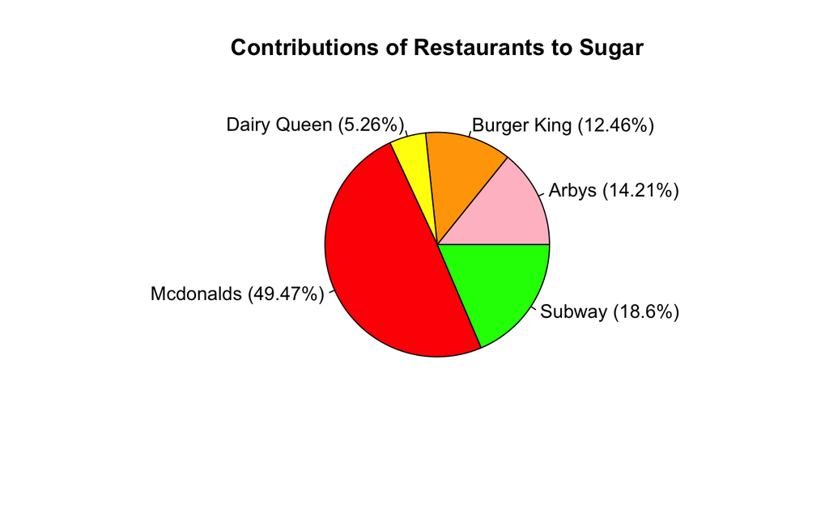

```r
top_20_sugar <- fastfood_df %>%
  arrange(desc(sugar)) %>%
  slice(1:20) %>%
  select(1,2,12)

restaurant_sugar <- aggregate(sugar ~ restaurant, data = top_20_sugar, FUN = sum)

total_sugar <- sum(restaurant_sugar$sugar)

restaurant_sugar$percentage <- round(restaurant_sugar$sugar / total_sugar * 100, 2)

colors <- c("pink", "orange", "yellow", "red", "green")
labels <- paste(restaurant_sugar$restaurant, " (", restaurant_sugar$percentage, "%)", sep = "")

pie(restaurant_sugar$sugar, labels = labels, col = colors, main = "Contributions of Restaurants to Sugar")
```

Answer: Food from Mcdonalds contributes the most total calories. Food from Burger King contributes the most saturated fats. Food from Subway contributes the most sodium. Food from Mcdonalds contributes the most sugar.

```r
top_items_calories <- top_20_calories %>%
  slice(1:3) %>%
  select(1,2)
print(top_items_calories)
```

| restaurant | item |
| --- | --- |
| Mcdonalds | 20 piece Buttermilk Crispy Chicken Tenders |
| Mcdonalds | 40 piece Chicken McNuggets |
| Mcdonalds | 10 piece Sweet N' Spicy Honey BBQ Glazed Tenders |

```r
top_items_satfats <- top_20_satfats %>%
  slice(1:3) %>%
  select(1,2)
print(top_items_satfats)
```

| restaurant | item |
| --- | --- |
| Burger King | American Brewhouse King |
| Dairy Queen | Large Cheese Curds |
| Sonic | Super Sonic Bacon Double Cheeseburger (w/mayo) |

```r
top_items_sodium <- top_20_sodium %>%
  slice(1:3) %>%
  select(1,2)
print(top_items_sodium)
```

| restaurant | item |
| --- | --- |
| Mcdonalds | 20 piece Buttermilk Crispy Chicken Tenders |
| Sonic | Buffalo Dunked Ultimate Chicken Sandwich |
| Mcdonalds | 10 piece Sweet N' Spicy Honey BBQ Glazed Tenders |

```r
top_items_sugar <- top_20_sugar %>%
  slice(1:3) %>%
  select(1,2)
print(top_items_sugar)
```

| restaurant | item |
| --- | --- |
| Mcdonalds | 10 piece Sweet N' Spicy Honey BBQ Glazed Tenders |
| Mcdonalds | 6 piece Sweet N' Spicy Honey BBQ Glazed Tenders |
| Burger King | Chicken, Apple & Cranberry Salad w/ Crispy Chicken |

Next steps: From this analysis we hope to more mindful of our fast food consumption and nutritional content. We can also gain a better understanding of the nutritional impact fast food has on our society, specifically in underresourced communities (i.e impoverished).

Citations: https://www.kaggle.com/datasets/ulrikthygepedersen/fastfood-nutrition https://www.fda.gov/food/new-nutrition-facts-label/how-understand-and-use-nutrition-facts-label#:~:text=Saturated%20fat%2C%20sodium%2C%20and%20added%20sugars%20are%20nutrients%20listed%20on,nutrients%20to%20get%20less%20of https://r-graph-gallery.com